# Reproducible Research: Course Project 1

## Rmarkdown for Course Project 1

This is a R Markdown document created at the end of “Reproducible Research” for the Coursera course “Peer Assessment 1” The assignment requires students, using markdown and R programming techniques, to write a R markdown document demonstrating literate programming. There are 5 main questions to be answered, which deal with data processing and analysis. The "activity monitoring data is the data provided to be worked on.

### Activity Monitoring Dataset

The data set used is Activity Monitoring Dataset

### Data Preprocessing

For the code to run correctly, the data must be in the user’s current working directory. Data from the zip file is extracted by the unzip function before it is read into R. In order to accelerate the reading process, the object classes contained within each of the variables are defined.

```r
unzip("repdata_data_activity.zip")
initialData <- read.csv("activity.csv", colClasses=c("numeric", "Date", "numeric"))
```

```r
head(initialData)
```

```
##   steps       date interval
## 1    NA 2012-10-01        0
## 2    NA 2012-10-01        5
## 3    NA 2012-10-01       10
## 4    NA 2012-10-01       15
## 5    NA 2012-10-01       20
## 6    NA 2012-10-01       25
```

```r
str(initialData)
```

```
## 'data.frame':    17568 obs. of  3 variables:
##  $ steps   : num  NA NA NA NA NA NA NA NA NA NA ...
##  $ date    : Date, format: "2012-10-01" "2012-10-01" ...
##  $ interval: num  0 5 10 15 20 25 30 35 40 45 ...
```

### Mean total number of steps taken per day

```r
data <- initialData[!(is.na(initialData$steps)), ]
```

The data must first be grouped individually for each day in order to determine the total number of steps taken per day and then the sum of each category is determined. Both of these steps can be completed by the aggregate function and the output is formatted in a tidy data frame.

```r
tSD <- aggregate(steps ~ date, data, sum)
head(tSD)
```

```
##         date steps
## 1 2012-10-02   126
## 2 2012-10-03 11352
## 3 2012-10-04 12116
## 4 2012-10-05 13294
## 5 2012-10-06 15420
## 6 2012-10-07 11015
```

Histogram is generated to indicate the frequency of total steps taken each day.

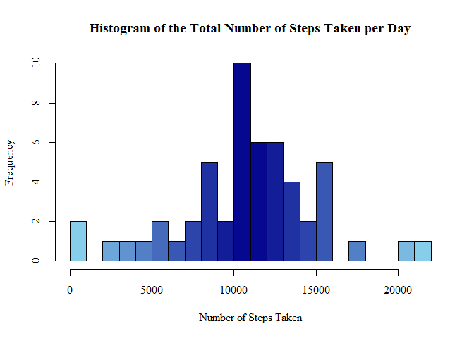

```r
paletteBlue <- colorRampPalette(c("skyblue", "darkblue", "skyblue"))
hist(tSD$steps, breaks=20, xlab="Number of Steps Taken",
     main="Histogram of the Total Number of Steps Taken per Day",
     col=paletteBlue(22), family="serif")
```

Finally, the summarise function can calculate the mean and median values of the total number of steps taken per day.

```r
library(dplyr)
totalStepsSummary <- summarise(tSD, meanOfTotalSteps=mean(tSD$steps),
                               medianOfTotalSteps=median(tSD$steps))
print(totalStepsSummary)
```

```
##   meanOfTotalSteps medianOfTotalSteps
## 1         10766.19              10765
```

mean value **10766.19** median value **10765**

### Average daily activity pattern

We can use another exploratory graph, this time a time series map, to look at the average daily trend. Since the average number of steps taken for each interval (using all days) can be looked at in this plot, the aggregate function must be used again to divide the data into groups for each interval and then to average the mean function.

```r
meanStepsInterval <- aggregate(steps ~ interval, data, mean)
head(meanStepsInterval)
```

```
##   interval     steps
## 1        0 1.7169811
## 2        5 0.3396226
## 3       10 0.1320755
## 4       15 0.1509434
## 5       20 0.0754717
## 6       25 2.0943396
```

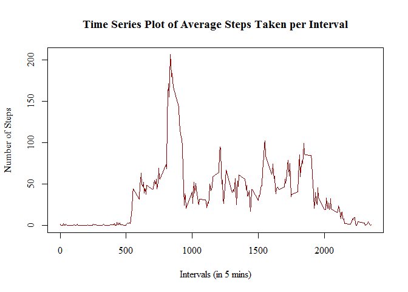

```r
plot(x=meanStepsInterval$interval, y=meanStepsInterval$steps, type="l",
     main="Time Series Plot of Average Steps Taken per Interval",
     ylab="Number of Steps", xlab="Intervals (in 5 mins)",
     col="darkred", lwd=1.5, family="serif")
```

```r
meanStepsInterval[grep(max(meanStepsInterval$steps), meanStepsInterval$steps), ]
```

```
##     interval    steps
## 104      835 206.1698
```

### Imputing missing values

As some of the observations can be checked to contain some NA values in the data:

```r
anyNA(initialData)
```

```
## [1] TRUE
```

```r
data.frame(steps=sum(is.na(initialData$steps)),
           interval=sum(is.na(initialData$interval)),
           date=sum(is.na(initialData$date)))
```

```
##   steps interval date
## 1  2304        0    0
```

```r
imputedData <- initialData
for(x in 1:17568) {
    if(is.na(imputedData[x, 1])==TRUE) {
        imputedData[x, 1] <- meanStepsInterval[meanStepsInterval$interval %in% imputedData[x, 3], 2]
    }
}
head(imputedData)
```

```
##       steps       date interval
## 1 1.7169811 2012-10-01        0
## 2 0.3396226 2012-10-01        5
## 3 0.1320755 2012-10-01       10
## 4 0.1509434 2012-10-01       15
## 5 0.0754717 2012-10-01       20
## 6 2.0943396 2012-10-01       25
```

```r
imputedTotalStepsDay <- aggregate(steps ~ date, imputedData, sum)
head(imputedTotalStepsDay)
```

```
##         date    steps
## 1 2012-10-01 10766.19
## 2 2012-10-02   126.00
## 3 2012-10-03 11352.00
## 4 2012-10-04 12116.00
## 5 2012-10-05 13294.00
## 6 2012-10-06 15420.00
```

Creating the histogram:

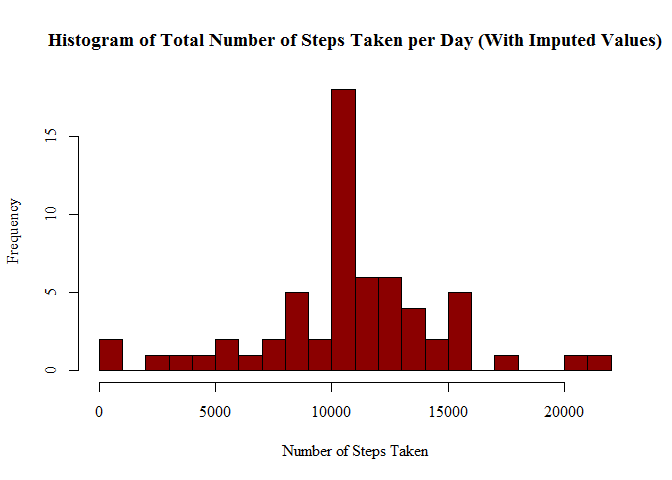

```r
paletteRed <- colorRampPalette(c("darkred", "darkred", "darkred"))
hist(imputedTotalStepsDay$steps, breaks=20, xlab="Number of Steps Taken",
     main="Histogram of Total Number of Steps Taken per Day (With Imputed Values)",
     col=paletteRed(22), family="serif")
```

```r
imputedStepsSummary <- summarise(imputedTotalStepsDay,
                                 meanOfTotalSteps=mean(imputedTotalStepsDay$steps),
                                 medianOfTotalSteps=median(imputedTotalStepsDay$steps))
print(imputedStepsSummary)
```

```
##   meanOfTotalSteps medianOfTotalSteps
## 1         10766.19           10766.19
```

```r
rbind(totalStepsSummary, imputedStepsSummary)
```

```
##   meanOfTotalSteps medianOfTotalSteps
## 1         10766.19           10765.00
## 2         10766.19           10766.19
```

### Are there differences in activity patterns between weekdays and weekends?

```r
dsData <- imputedData
dsData$days <- weekdays(dsData$date)
dsData$weekday <- as.character(rep(0, times=17568))
for(x in 1:17568) {
    if(dsData[x, 4] %in% c("Saturday", "Sunday")) {
        dsData[x, 5] <- "weekend"
    } else {
        dsData[x, 5] <- "weekday"
    }
}
dsData$weekday <- factor(dsData$weekday)
head(dsData)
```

```
##       steps       date interval   days weekday
## 1 1.7169811 2012-10-01        0 Monday weekday
## 2 0.3396226 2012-10-01        5 Monday weekday
## 3 0.1320755 2012-10-01       10 Monday weekday
## 4 0.1509434 2012-10-01       15 Monday weekday
## 5 0.0754717 2012-10-01       20 Monday weekday
## 6 2.0943396 2012-10-01       25 Monday weekday
```

The data has to be divided into two classes of weekday/weekend data to compare the weekday and weekend data and create two plots of the average number of steps taken per interval, using the newly created variable.

```r
weekdayData <- dsData[dsData$weekday=="weekday", ]
weekendData <- dsData[dsData$weekday=="weekend", ]
```

```r
wkdayMean <- aggregate(steps ~ interval, weekdayData, mean)
weekendMean <- aggregate(steps ~ interval, weekendData, mean)
```

The panel plot is ultimately established. Each 5 minute interval is shown by the x axis and the y axis displays the average number of steps taken. Both plots are split into data for weekdays and weekends.

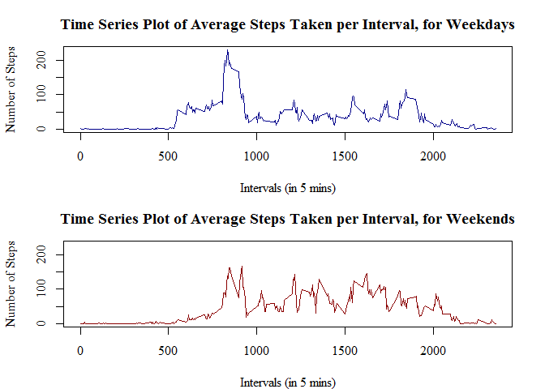

```r
par(mfrow=c(2, 1), mar=c(4, 4.1, 3, 2.1))
plot(wkdayMean$interval, wkdayMean$steps, type="l",
     main="Time Series Plot of Average Steps Taken per Interval, for Weekdays",
     xlab="Intervals (in 5 mins)", ylab="Number of Steps", family="serif",
     col="darkblue", lwd=1.5, ylim=c(0, 230))
plot(weekendMean$interval, weekendMean$steps, type="l",
     main="Time Series Plot of Average Steps Taken per Interval, for Weekends",
     xlab="Intervals (in 5 mins)", ylab="Number of Steps", family="serif",
     col="darkred", lwd=1.5, ylim=c(0, 230))
```